# Econometría Aplicada con R

Sesión 03: Modelos no lineales y dinámicos

Javier Emmanuel Anguiano Pita

SECIHTI-Universidad de Guadalajara

17 de junio de 2026

## Agenda del día

1. Modelos con variables dicotómicas
2. Regresiones no lineales
3. Modelos dinámicos

# Introducción

## Plan del día

En esta sesión extendemos el MRL en dos direcciones:

**Extensiones del modelo clásico:**

- Variables dicotómicas: incorporar información cualitativa.
- Formas funcionales: capturar relaciones no lineales.
- Pruebas de especificación del modelo (RESET Ramsey)

**Más allá del corte transversal:**

- Modelos dinámicos: incorporamos el tiempo como dimensión analítica.
- Persistencia de los efectos temporales.

## Variables dicotómicas

Una variable dicotómica (*dummy*) codifica información cualitativa como valor numérico:

$$d_i = \begin{cases} 1 & \text{si la condición se cumple} \\ 0 & \text{en caso contrario} \end{cases}$$

**¿Por qué es útil?**

- Permite incorporar características no cuantificables al modelo de regresión
- Sexo, sector económico, región geográfica, período de crisis

## Variables dicotómicas

Supongamos que queremos estimar el siguiente modelo:

$$wage_i = \beta_0 + \delta \, female_i + \beta_1 \, educ_i + \varepsilon_i$$

- Si $female = 0$ (hombre): $E[wage] = \beta_0 + \beta_1 \, educ$
- Si $female = 1$ (mujer): $E[wage] = (\beta_0 + \delta) + \beta_1 \, educ$
- El coeficiente $\delta$ captura el **desplazamiento del intercepto** entre grupos

## Interpretación del coeficiente $\delta$

Variable dependiente: $wage$

| Variable | Coeficiente | Error estándar | Estadístico t | P-value | Significancia |
| --- | --- | --- | --- | --- | --- |
| (Intercept) | -1.5679 | 0.7246 | -2.1640 | 0.0309 | ** |
| female | -1.8109 | 0.2648 | -6.8379 | 0.0000 | *** |
| educ | 0.5715 | 0.0493 | 11.5836 | 0.0000 | *** |
| exper | 0.0254 | 0.0116 | 2.1951 | 0.0286 | ** |
| tenure | 0.1410 | 0.0212 | 6.6632 | 0.0000 | *** |

*** p<0.01, ** p<0.05, * p<0.1

$\hat{\delta}$ es la diferencia salarial promedio entre mujeres y hombres, **manteniendo constantes** educación, experiencia y antigüedad

## La trampa de la variable dicotómica

Esta situación ocurre cuando se incluyen todas las categorías de una variable dicotómica en un modelo de regresión.

Supongamos que queremos estimar el siguiente modelo:

$$wage_i = \beta_0 + \delta \, female_i + \gamma \, male_i + \beta_1 \, educ_i + \varepsilon_i$$

Donde:

$$female_i = \begin{cases} 1 & \text{si se trata de una mujer} \\ 0 & \text{en caso contrario} \end{cases}$$
$$male_i = \begin{cases} 1 & \text{si se trata de un hombre} \\ 0 & \text{en caso contrario} \end{cases}$$

## Estimación en R

Estimamos el modelo incluyendo el género en dos categorias: `female` y `male`.

```r
wage1 <- wage1 |>
  mutate(male = 1 - female)

m_trampa <- lm(wage ~ female + male + educ,
               data = wage1)
```

| Variable | Coeficiente | Error estándar | Estadístico t | P-value | Significancia |
| --- | --- | --- | --- | --- | --- |
| (Intercept) | 0.6228 | 0.6725 | 0.9261 | 0.3548 |  |
| female | -2.2734 | 0.2790 | -8.1470 | 0.0000 | *** |
| male | NA | NA | NA | NA |  |
| educ | 0.5065 | 0.0504 | 10.0505 | 0.0000 | *** |

**¿Qué observas?**

R elimina automáticamente `male` porque existe **multicolinealidad perfecta**:

$$female_i + male_i = 1 \quad \forall i$$

**Regla:** si una variable categórica tiene $k$ categorías, incluye $k - 1$ dummies.

## Múltiples categorías

Supongamos que ahora queremos clasificar el número de años de educación mediante umbrales/niveles educativos:

$$educ_i = \begin{cases} 1 & \text{educ < 12 años "No completó preparatoria"} \\ 2 & \text{educ == 12 años "Preparatoria"} \\
3& \text{educ > 12 años "Universidad" }\end{cases}$$

Queremos estimar el siguiente modelo:

$$wage_i = \beta_0 + \delta_i educ_{i} + \beta_1 exper_i + \beta_2 tenure_i + \varepsilon_i$$

## Recodificación con factores

Para generar automáticamente nuestras variables dicotómicas podemos utilizar factores

```
 Factor w/ 3 levels "Sin_preparatoria",..: 1 2 1 1 2 3 3 2 2 3 ...
```

| Variable | Coeficiente | Error estándar | Estadístico t | P-value | Significancia |
| --- | --- | --- | --- | --- | --- |
| (Intercept) | 2.9134 | 0.3707 | 7.8584 | 0.0000 | *** |
| educ_catPreparatoria | 1.6018 | 0.3765 | 4.2543 | 0.0000 | *** |
| educ_catUniversidad | 3.4785 | 0.3792 | 9.1741 | 0.0000 | *** |
| exper | 0.0049 | 0.0123 | 0.3999 | 0.6894 |  |
| tenure | 0.1752 | 0.0226 | 7.7452 | 0.0000 | *** |

La categoría de referencia es `Sin_preparatoria` — los coeficientes se interpretan en relación a ella

## Interacciones dummy × continua

Una interacción permite que la **pendiente** también cambie entre grupos, no solo el intercepto.

$$wage_i = \beta_0 + \delta \, female_i + \beta_1 \, educ_i + \gamma \, (female_i \times educ_i) + \varepsilon_i$$

- **Hombres:** $\partial wage / \partial educ = \beta_1$
- **Mujeres:** $\partial wage / \partial educ = \beta_1 + \gamma$

Si $\gamma < 0$, cada año adicional de educación tiene **menor retorno** para las mujeres

## Estimación en R

```r
m_interaccion <- lm(wage ~ female * educ + exper + tenure,
                    data = wage1)
summary(m_interaccion)
```

| Variable | Coeficiente | Error estándar | Estadístico t | P-value | Significancia |
| --- | --- | --- | --- | --- | --- |
| (Intercept) | -2.2746 | 0.8723 | -2.6077 | 0.0094 | *** |
| female | -0.0600 | 1.2348 | -0.0486 | 0.9613 |  |
| educ | 0.6258 | 0.0619 | 10.1162 | 0.0000 | *** |
| exper | 0.0256 | 0.0116 | 2.2175 | 0.0270 | ** |
| tenure | 0.1423 | 0.0212 | 6.7268 | 0.0000 | *** |
| female:educ | -0.1397 | 0.0963 | -1.4516 | 0.1472 |  |

La categoría de referencia son los hombres.

## Visualizando la interacción

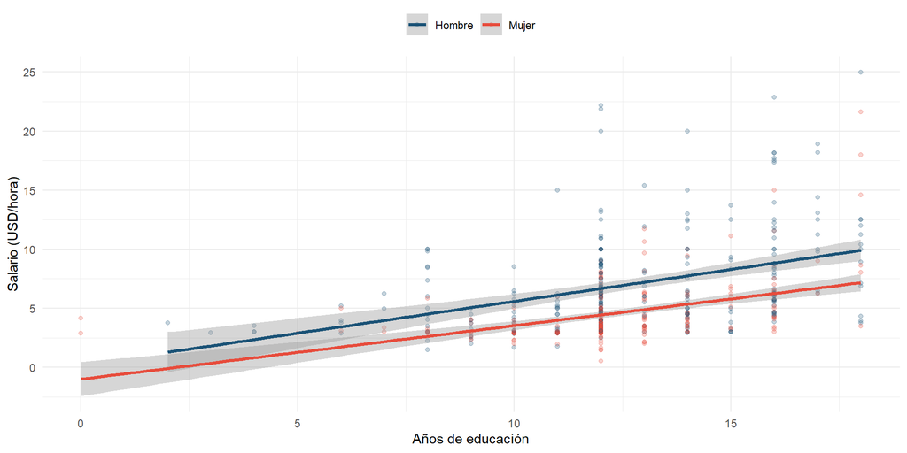

# Fin del primer bloque 🗣

# Formas funcionales

## Introducción

La linealidad es un supuesto sobre los **parámetros**, no sobre las variables:

$$y = \beta_0 + \beta_1 x \quad \text{vs} \quad \ln y = \beta_0 + \beta_1 \ln x$$
$$y = \beta_0 + \beta_1 x \quad \text{vs} \quad \ln y = \beta_0 + \beta_1 \ x^2$$

Ambos se estiman por MCO — la diferencia está en la **interpretación**.

**¿Por qué importa la forma funcional?**

- Las relaciones económicas rara vez son lineales
- El retorno a la educación decrece con los años de escolaridad
- El efecto de la experiencia en el salario tiene un punto de inflexión
- Una especificación incorrecta sesga los coeficientes

Regla práctica: deja que la teoría económica guíe la elección de la forma funcional, luego verifica con los datos

## Resumen de formas funcionales

| Modelo | Ecuación | Interpretación de β₁ | En R |
| --- | --- | --- | --- |
| Lineal | \(y = \beta_0 + \beta_1 x\) | \(\Delta x = 1 \Rightarrow \Delta y = \beta_1\) | wage ~ educ |
| Log-log | \(\ln y = \beta_0 + \beta_1 \ln x\) | Elasticidad: \(\Delta x = 1\% \Rightarrow \Delta y = \beta_1\%\) | log(wage) ~ log(educ) |
| Log-lin | \(\ln y = \beta_0 + \beta_1 x\) | Semielasticidad: \(\Delta x = 1 \Rightarrow \Delta y = \beta_1 \times 100\%\) | log(wage) ~ educ |
| Lin-log | \(y = \beta_0 + \beta_1 \ln x\) | \(\Delta x = 1\% \Rightarrow \Delta y = \beta_1 / 100\) | wage ~ log(educ) |
| Cuadrático | \(y = \beta_0 + \beta_1 x + \beta_2 x^2\) | \(\partial y/\partial x = \beta_1 + 2\beta_2 x\) | wage ~ exper + I(exper^2) |

## Estimación en R

```r
library(wooldridge)
data("wage1")

# Lineal
m_lineal  <- lm(wage ~ educ, data = wage1)

# Log-log
m_loglog  <- lm(log(wage) ~ log(educ), data = wage1)

# Log-lin
m_loglin  <- lm(log(wage) ~ educ, data = wage1)

# Lin-log
m_linlog  <- lm(wage ~ log(educ), data = wage1)

# Cuadrático
m_cuad    <- lm(wage ~ exper + I(exper^2), data = wage1)
```

`I()` protege la expresión para que R la evalúe como operación aritmética, no como fórmula de modelo

## El efecto cuadrático de la experiencia

$$\widehat{wage}_i = \beta_0+\beta_1 \ exper_i + \beta_2 \ exper^2_i+ e_i$$
**Punto de máximo:**

$$\hat{exper}^* = -\frac{\hat{\beta}_1}{2\hat{\beta}_2}$$

## Efecto cuadrático de la experiencia

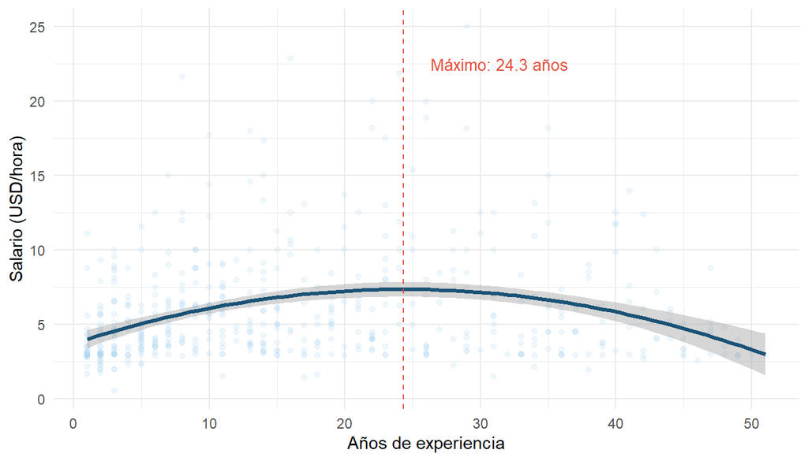

## Prueba RESET de Ramsey (1969)

**¿Para qué la usamos**

Sirve para detectar si un modelo de regresión está mal especificado.

Busca evidencia de que la relación entre $Y$ y las variables explicativas no está siendo capturada adecuadamente por la forma funcional elegida.

**Hipótesis:**
$$H0: \text{El modelo está correctamente especificacado}$$
$$H1: \text{Existe algún error de especificación}$$

## Regression Equation Specification Error Test

**¿Qué tipo de problemas puede detectar?**

1. **Variables omitidas**
2. **Forma funcional incorrecta**
3. **Transformaciones de datos incorrecta**

**Nota**

La prueba no indica qué **está mal**. Solo indica que algo está fallando con el modelo.

## Prueba RESET de Ramsey (1969)

**¿Cómo funciona?**

1. Estimamos nuestro modelo de regresión.
2. Calculamos los valores ajustados ($\hat{Y}$).
3. Generamos potencias de $\hat{Y}$: $\hat{Y}^2, \hat{Y}^3,...,\hat{Y}^n$
4. Estimamos la siguiente regresión auxiliar:

$$y = X\beta + \gamma_1 . \hat{y}^2 + \gamma_2 . \hat{y}^3 + ... + \gamma_n . \hat{y}^n+e_i$$

$$H0: \gamma_1 = \gamma_2 = ... = \gamma_n = 0$$
$$H1: \text{ al menos uno de los } \gamma_h \neq 0$$

## Estimación en R

Usamos la función `resettest()` contenida en la librería `lmtest`.

```r
library(lmtest)

m_lineal <- lm(wage ~ educ, data = wage1)
resettest(m_lineal, power = 2:3, type = "fitted")
```

```
    RESET test

data:  m_lineal
RESET = 13.382, df1 = 2, df2 = 522, p-value = 2.15e-06
```

# Fin del segundo bloque 🗣

# Modelos dinámicos

## Modelos dinámicos

En economía, los efectos rara vez son instantáneos:

- Una política monetaria tarda meses en transmitirse al nivel de precios
- El impacto de la IED sobre el crecimiento económico puede manifestarse con rezago
- El consumo de hoy depende del ingreso de hoy **y del pasado**

**Idea central:** incorporar el tiempo como dimensión analítica dentro del modelo de regresión

$$y_t = \beta_0 + \beta_1 x_t + \beta_2 x_{t-1} + \cdots + \varepsilon_t$$

El pasado de $x$ es un regresor más — se estima por **MCO**

# Modelos autorregresivos

## Modelo autorregresivo AR(1)

$$y_t = \alpha + \phi \, y_{t-1} + \varepsilon_t$$

**Implicación técnica**

- El regresor es la propia variable dependiente rezagada un período
- Se estima por MCO, pero requiere **exogeneidad contemporánea**, no estricta
- Si $|\phi| < 1$ el proceso es estable — los choques se disipan con el tiempo
- Si $\phi \geq 1$ el proceso es explosivo — los choques se acumulan

**Implicación económica**

- Captura **inercia** o **persistencia** en el comportamiento de los agentes
- El consumo de hoy depende del consumo de ayer — hábito de consumo
- Las expectativas adaptativas generan estructuras AR en muchas series macroeconómicas

$\phi$ mide qué tan rápido se disipa un choque — cuanto más cercano a 1, más lenta la recuperación

## Estabilidad vs. explosividad en AR(1)

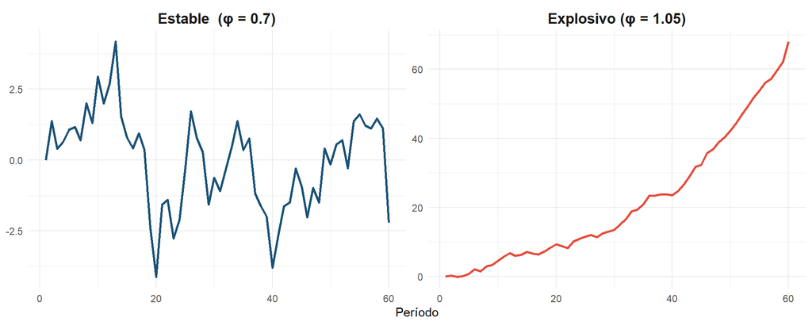

Con $|\phi| < 1$ los choques se disipan y la serie revierte a su media — con $\phi \geq 1$ los choques se acumulan y la serie diverge

## Proceso AR(1): Ejemplo

Supongamos que queremos modelar el comportamiento del logaritmo de la inversión en vivienda en EE.UU para los años 1947-1988 mediante la siguiente ecuación:

$$inv_t = \beta_0 + \beta_1 .\ inv_{t-1}+ e_t$$

| Variable | Coeficiente | Error estándar | Estadístico t | P-value | Significancia |
| --- | --- | --- | --- | --- | --- |
| (Intercept) | -0.2324 | 0.0847 | -2.7438 | 0.0091 | *** |
| L(linvpc, 1) | 0.6340 | 0.1222 | 5.1896 | 0.0000 | *** |

## Modelo ARDL

$$y_t = \beta_0 + \phi \, y_{t-1} + \beta_1 x_t + \beta_2 x_{t-1} + \varepsilon_t$$

**Implicación técnica**

- Combina el modelo AR con rezagos distribuidos de los regresores
- Se estima por MCO — es una regresión lineal múltiple con variables rezagadas
- La estructura de rezagos óptima se determina con criterios de información (AIC, BIC)
- Permite separar efectos de **corto** y **largo plazo**

**Implicación económica**

- Un cambio en $x_t$ afecta a $y_t$ de forma inmediata ($\beta_1$) y con retardo ($\beta_2$)
- La persistencia de $y$ amplifica o amortigua ese efecto en el tiempo
- Es especialmente útil cuando los datos son anuales y los ajustes son graduales

## Efectos de corto y largo plazo

$$y_t = \beta_0 + \phi \, y_{t-1} + \beta_1 x_t + \beta_2 x_{t-1} + \varepsilon_t$$

**Efecto de corto plazo** — impacto inmediato de $x$ sobre $y$:

$$\frac{\partial y_t}{\partial x_t} = \beta_1$$

**Efecto de largo plazo** — impacto total una vez que el sistema se estabiliza:

$$\theta = \frac{\beta_1 + \beta_2}{1 - \phi}$$

Si $\phi > 0$ el efecto de largo plazo es mayor que el de corto plazo — la persistencia de $y$ amplifica el impacto inicial de $x$

## Aplicación: emisiones de CO₂ en México

**Anguiano Pita (2026)** — *Determinantes de las emisiones de CO₂ en América del Norte*

**¿Por qué un modelo ARDL?**

Las variables económicas y ambientales ajustan gradualmente — un modelo estático subestimaría el efecto total de cada regresor

**Variable dependiente:** emisiones de CO₂ (kt), 1970-2023

**Regresores:**

- $PIB_t$ y $PIB_t^2$ — hipótesis de la Curva Ambiental de Kuznets (CAK)
- $ENE_t$ — consumo de energía
- $IED_t$ — inversión extranjera directa
- $AC_t$ — apertura comercial

Series anuales del Banco Mundial, Andrew y Peters (2024) y Energy Institute (2024)

# Datos

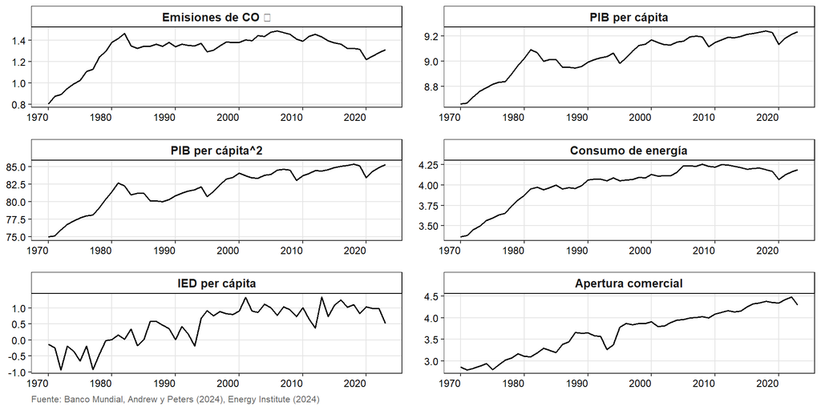

## Estadística descriptiva

Período de análisis: 1970-2023

|  | Mean | SD | Min | Max | N |
| --- | --- | --- | --- | --- | --- |
| PIB_MX | 8626.20 | 1240.62 | 5774.77 | 10296.87 | 54 |
| CO2PC_MX | 3.75 | 0.52 | 2.24 | 4.42 | 54 |
| FDI_MX | 1.87 | 0.91 | 0.39 | 3.84 | 54 |
| TRADE_MX | 44.44 | 20.83 | 16.36 | 88.39 | 54 |
| ENE_MX | 56.47 | 11.60 | 28.92 | 70.68 | 54 |
| PIB2_MX | 2.4e+36 | 3.2e+36 | 3.8e+32 | 1.2e+37 | 54 |

Esta tabla se calcula con las series en niveles (i.e. valores observados).

## Correlaciones “pair-wise”

|  | PIB_MX | CO2PC_MX | FDI_MX | TRADE_MX | ENE_MX | PIB2_MX |
| --- | --- | --- | --- | --- | --- | --- |
| PIB_MX | 1 | . | . | . | . | . |
| CO2PC_MX | .8196*** | 1 | . | . | . | . |
| FDI_MX | .8128*** | .6409*** | 1 | . | . | . |
| TRADE_MX | .8887*** | .5989*** | .8618*** | 1 | . | . |
| ENE_MX | .9510*** | .8961*** | .8129*** | .8658*** | 1 | . |
| PIB2_MX | 1.0000*** | .8154*** | .8136*** | .8905*** | .9494*** | 1 |

Las series las trabajaremos en términos de logaritmos naturales.

No modelamos PIB2_MX para evitar problemas de multicolinealidad perfecta.

## Estimación del modelo ARDL

En este ejercicio estimaremos el siguiente modelo:

$$CO2_t = \alpha_0 + \sum_{i=1}^{p} \phi_i \, CO2_{t-i} + \sum_{j=0}^{q_1} \beta_{1j} \, PIB_{t-j} +$$

$$\sum_{j=0}^{q_2} \beta_{3j} \, ENE_{t-j} + \sum_{j=0}^{q_3} \beta_{4j} \, IED_{t-j} + \sum_{j=0}^{q_4} \beta_{5j} \, AC_{t-j} + \varepsilon_t$$

Donde:

- $CO2_t$ — emisiones de CO₂ per cápita
- $PIB_t$ — hipótesis de la Curva Ambiental de Kuznets
- $ENE_t$ — consumo de energía per cápita
- $IED_t$ — inversión extranjera directa per cápita
- $AC_t$ — apertura comercial

Todas las variables en logaritmos naturales — la estructura de rezagos óptima $(p, q_1, q_2, q_3, q_4)$ se determina mediante el criterio de información de Akaike (AIC)

## Estimación en `R`

Mi recomendación es usar la librería `ARDL`. Existen otras pero esta es la que tiene mejor documentación.

**Pasos a seguir:**

1. Determinar el número de rezagos por variable.
2. Estimar el modelo ARDL mediante MCO.
3. Calcular los efectos de corto y largo plazo.
4. Pruebas de diagnóstico al modelo.

🚨 En este momento no nos vamos a preocupar por las propiedades de cointegración de las series.

## Resultados del modelo

| Variable | Coeficiente | Error estándar | Estadístico t | P-value | Significancia |
| --- | --- | --- | --- | --- | --- |
| (Intercept) | -1.7880 | 0.8215 | -2.1766 | 0.0363 | ** |
| L(CO2PC_MX, 1) | 0.6615 | 0.1330 | 4.9738 | 0.0000 | *** |
| L(CO2PC_MX, 2) | 0.4232 | 0.1639 | 2.5815 | 0.0142 | ** |
| L(CO2PC_MX, 3) | -0.4677 | 0.1288 | -3.6322 | 0.0009 | *** |
| PIB_MX | 0.5704 | 0.1318 | 4.3274 | 0.0001 | *** |
| L(PIB_MX, 1) | -0.2328 | 0.1703 | -1.3674 | 0.1802 |  |
| L(PIB_MX, 2) | -0.5868 | 0.1780 | -3.2967 | 0.0022 | *** |
| L(PIB_MX, 3) | 0.0949 | 0.1720 | 0.5516 | 0.5847 |  |
| L(PIB_MX, 4) | 0.3672 | 0.1162 | 3.1608 | 0.0032 | *** |
| ENE_MX | 0.2115 | 0.1220 | 1.7337 | 0.0918 | * |
| FDI_MX | 0.0155 | 0.0139 | 1.1125 | 0.2735 |  |
| L(FDI_MX, 1) | 0.0049 | 0.0135 | 0.3632 | 0.7187 |  |
| L(FDI_MX, 2) | 0.0199 | 0.0135 | 1.4682 | 0.1510 |  |
| TRADE_MX | -0.0623 | 0.0447 | -1.3929 | 0.1724 |  |
| L(TRADE_MX, 1) | -0.0729 | 0.0462 | -1.5774 | 0.1237 |  |

## Resultados de largo plazo

```r
mlp <- multipliers(m_ardl, type = "lr")

print(mlp)
```

```
         Term   Estimate Std. Error   t value     Pr(>|t|)
1 (Intercept) -4.6673112 2.14404105 -2.176876 3.632184e-02
2      PIB_MX  0.5555016 0.31409029  1.768605 8.567530e-02
3      ENE_MX  0.5521212 0.19814207  2.786491 8.548267e-03
4      FDI_MX  0.1051119 0.05688742  1.847719 7.310879e-02
5    TRADE_MX -0.3528906 0.07389379 -4.775646 3.153582e-05
```

## Resultados de corto plazo

```r
mcp <- multipliers(m_ardl, type = "sr")

print(mcp)
```

```
         Term    Estimate Std. Error   t value     Pr(>|t|)
1 (Intercept) -1.78798017 0.82145474 -2.176602 0.0363438959
2      PIB_MX  0.57042309 0.13181733  4.327375 0.0001199012
3      ENE_MX  0.21150972 0.12199853  1.733707 0.0917723541
4      FDI_MX  0.01548864 0.01392257  1.112484 0.2735130212
5    TRADE_MX -0.06232629 0.04474572 -1.392899 0.1724353035
```

# Fin de la sesión 🕺🏿